# hw1_gz2280

## HW1

### Gehua Zhang (UNI:gz2280)

### Sep 19, 2018

### Problem 1a.

$\bullet$ For graph (i):

First of all, obtain the PTM from graph:

$$ PTM_{i} = \begin{bmatrix}0 & 0.5 & 0 & 0.5 \\ 0.5 & 0 & 0.5 & 0 \\ 0 & 0 & 1 & 0 \\ 0 & 0 & 0 & 1\end{bmatrix} $$

To find the invariant distribution, assume our invariant measure is $\mu$, thus we have $\mu \mathbf P = \mu$. Let $\mu = (s_1,s_2,s_3,s_4)$, we have the following polynomials:

$$ 0.5 s_2 = s_1 \\ 0.5 s_1 = s_2 \\ 0.5 s_2 + s_3= s_3 \\0.5 s_1 + s_4 = s_4 \\ s_1+s_2+s_3+s_4=1 $$

Solved: $s_1 = s_2 = 0, s_3+s_4 = 1$.

So graph (i) does have an invariant distribution $(0,0,a,1-a)$ for any $a \in \mathbb R$.

To show that $\mu$ is not unique, from Theorem, we require to check properties of $PTM_i$:

1) Irreducible

False.

Clearly observed from graph that this is not irreducible. For example, starting from state 4 we can never reach state 1, 2, 3, and from state 3 we can never reach state 1, 2, 4.

2) Aperiodic (Ergodicity)

False.

From $PTM_i$ the first and second diagonals are zero, which against the requirement of aperiodic that PTM has no zero diagonal.

**$\mu=(0,0,𝑎,1−𝑎)$ for any $a \in \mathbb R$.Thus this invariant distribution is not unique.**

$\bullet$ For graph (ii):

$$ PTM_{ii} = \begin{bmatrix}0 & 1 & 0 \\ 0 & 0 & 1 \\ 1 & 0 & 0\end{bmatrix} $$

Let $\mu = (s_1,s_2,s_3)$, $\mu \mathbf P = \mu$ we have:

$$ s_1=s_2=s_3 \\ s_1+s_2+s_3=1 $$

Thus $\mu = (\frac{1}{3},\frac{1}{3},\frac{1}{3})$.

To test that if 𝜇 is unique:

1) Irreducible

True.

We can access any states with any starting points.

2) Aperiodic (Ergodicity):

False.

The diagonal values of $PTM_2$ are all zeros. From definition, $p_{s \to s} = 0$, thus it's not aperiodic.

**$\mu=(\frac{1}{3},\frac{1}{3},\frac{1}{3})$ .Thus this invariant distribution is not unique.**

### Problem 1b.

First allow me use my own words to define: i.i.d., Markov model and hidden Markov model:

1) i.i.d.

Independent outcomes which share a same distribution.

2) Markov model

Every state is only related to its previous one state, conditionally independent of other previous states.

3) Hidden Markov model

We observe the outcome of a system which is built on Markov model, but we aren't so sure about what's going on in some middle points.

Then check the gambler's fallacy based on a set of outcomes: $(X_1,X_2,X_3...X_n)$：

1) i.i.d.

False.

From the definition of gambler's fallacy we know that if "lucky streak" appears more often in the current, we expect "unlucky streak" appears more in the future. Thus $X_1,X_2,X_3...X_n$ would not be independent. Let's say,

$$ P(X_{100}="lucky"|X_{99}=X_{98}=...X_{1}="unlucky") > P(X_{100}="lucky") $$

Which against the rule of independency that they should be equal.

2) Markov model

False.

Gambler's fallacy could be a Markov model once we elimate "neutral" state. However, if there is a "neutral" state, it should be independent of "lucky" and "unlucky" and the Markov model is destroyed. Considering the following outcome sequence: (Denote "lucky" as $L$, "unlucky" as $U$, "neutral" as $N$, and subscript as the order of the experiment)

$$ L_1 \to L_2 \to U_3 \to L_4 \to N_5 \to L_6 \to U_7 $$

Clearly the beginning 4 experiments are Markov model, due to the fact that they are conditionally independent of previous states. However, from 5th experiment to 6th experiment, we could not find a relation of "netural" and "lucky". Gambler's fallacy never states the dependency of being "netural" and being "lucky", which allows us assume that they are independent. So from 5th to 6th, the Markov model breaks.

3) Hidden Markov model

False.

We could not find a trasition matrix from our situation. As we stated above, "neutral" is indepent of "lucky" or "unlucky".

### Problem 2a.

```python
import numpy as np
from scipy import linalg

def GSAMPLE(mu, Sigma, n):

  d = np.shape(mu)[0]  # dimension
  normal_mean, normal_sigma = np.zeros(d), np.diag(np.ones(d))  # parameters for generate g
  vec_g = np.random.multivariate_normal(normal_mean,normal_sigma,n)  # g is a n by d matrix: n samples, d variables
  mat_D, mat_V = linalg.schur(Sigma)  # Schur decomposition
  sqrt_D = linalg.sqrtm(mat_D)  # sqrt of matrix D

  G = np.dot(np.dot(mat_V,sqrt_D),np.transpose(vec_g))
  G = np.transpose(G)+mu

  return(G)
```

### Problem 2b.

Test for 1-d situation. Let $\mu=[10], \ \Sigma = [4], \ n = 1000$:

```python
d1Value = GSAMPLE(np.array([10]),np.matrix(4),1000)

print(np.mean(d1Value,axis=0))
print(np.cov(np.transpose(d1Value)))
```

```
[10.01209147]
3.892259603012713
```

Test for 2-d situation. Let $\mu=[5,10], \ \Sigma = \begin{bmatrix} 4 & 3 \\3 & 4\end{bmatrix}, \ n = 1000$:

```python
d2Value = GSAMPLE(np.array([5,10]),np.matrix([[4,3],[3,4]]),1000)

print(np.mean(d2Value,axis=0))
print(np.cov(np.transpose(d2Value)))
```

```
[4.85728125 9.86230756]
[[3.99203381 2.97552745]
 [2.97552745 4.01012573]]
```

```python
d3Value = GSAMPLE(np.array([7,23,46]),np.matrix([[21,0,0],[0,17,0],[0,0,6]]),1000)

print(np.mean(d3Value,axis=0))
print(np.cov(np.transpose(d3Value)))
```

```
[ 7.01105786 22.97836656 45.94171208]
[[19.43456738  0.35102401 -0.35226393]
 [ 0.35102401 17.4986081  -0.0344696 ]
 [-0.35226393 -0.0344696   6.09917252]]
```

### Problem 2c.

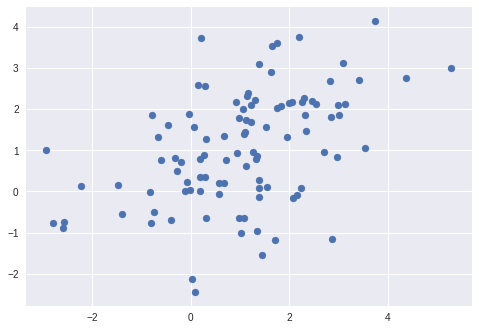

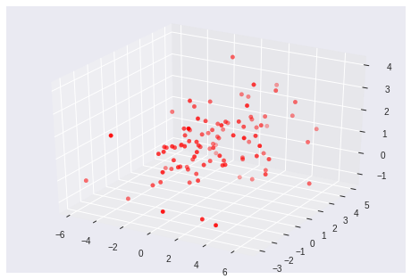

```python
from mpl_toolkits.mplot3d import Axes3D
import matplotlib.pyplot as plt

G2 = GSAMPLE(np.array([1,1]),np.matrix([[2,1],[1,2]]),100)
G3 = GSAMPLE(np.array([1,1,1]),np.matrix([[5,2,0],[2,3,1],[0,1,1]]),100)

fig1 = plt.figure()
plot1 = plt.scatter(G2[:,0],G2[:,1])  # plot for 2d samples

fig2 = plt.figure()
ax = fig2.add_subplot(111, projection='3d')  # plot for 3d samples
Axes3D.scatter(ax,G3[:,0],G3[:,1],G3[:,2],c="red")
```

### Problem 3a.

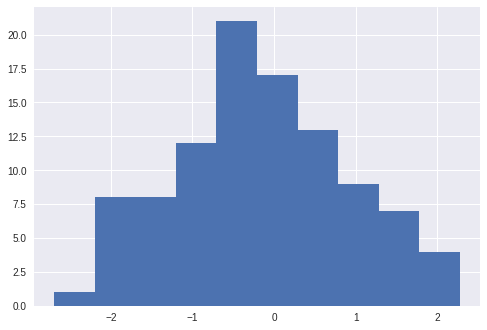

```python
import matplotlib.pyplot as plt
import numpy as np

def histGenerator(n,Nbins):
  seed = np.random.randn(n)
  plot_temp = plt.hist(seed, Nbins)
  return plot_temp

plot1 = histGenerator(100,10)
```

### Problem 3b.

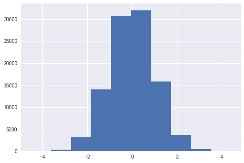

```python
plot2 = histGenerator(100000,10)
```

### Problem 3c.

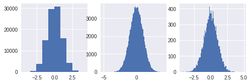

```python
plt.subplot(2,3,1)
plot3 = histGenerator(100000,10)
plt.subplot(2,3,2)
plot4 = histGenerator(100000,100)
plt.subplot(2,3,3)
plot5 = histGenerator(100000,1000)
```

### Problem 3d.

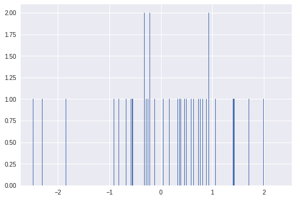

```python
plot6 = histGenerator(100,1000)
```

### Problem 3e.

Observed rules: (For data sampling from standard normal dirstribution)

- (plot1 to plot2) If we fix the number of bins of a histogram and increasing the volume of sample size, we'd get a graph which is closer to normal distribution, thus a better estimate.
- (plot3, plot4 to plot5) If we fix the size of samples and increasing the bins, we would observe a smoother fit, but it would become rough again if the bin number keeps increasing. This process could be considered as the ratio $\frac{n}{N_{bins}}$ is decreasing. As the ratio decreases, some points in the middle give us the best fit.
- (plot6) If our bin number is greater than the sample size, our graph may look weird since bars are discrete. This is true that we have to distribute limited samples to a broader range. This does not seem to be a good fit and normal distribution can be rarely observed.